# CMS Final Project

Christopher Reddish

Khushi Patel

Naomi Vaid

Sneh Patel

Scott Young

Steven Barden

04/27/2025

# Introduction

This project analyzes Medicare provider data for the Tampa Bay region to understand service patterns, cost structures, and geopgraphic distributions. We utilize association rule mining, k-means clustering, linear regression, and geospatial visualization to explore relationships within the data. The primary data source is the CMS Medicare Provider Utilization and Payment Data Public Use File. Our goal is to identify key trends and factors influencing healthcare delivery and costs in this specific geographic area.

# Setup: Loading Libraries and Data

## Load Required Libraries

```r
# Add your library below.
# List of required packages
required_packages <- c(
  "tidyverse",
  "GGally",
  "ggplot2",
  "sf",
  "dplyr",
  "readr",
  "arules",
  "leaflet",
  "tigris",
  "scales",
  "htmlwidgets",
  "jsonlite",
  "purrr",
  "stringr",
  "lme4",
  "broom.mixed"
)

# Install any packages that are not already installed
to_install <- setdiff(required_packages, rownames(installed.packages()))
if (length(to_install) > 0) {
  install.packages(to_install, dependencies = TRUE)
}

# Load all required packages and check if successfully loaded
for (pkg in required_packages) {
  if (!require(pkg, character.only = TRUE)) {
    warning(sprintf("Package '%s' could not be loaded.", pkg))
  }
}
```

[output not shown]

```r
# Enable caching for tigris package
options(tigris_use_cache = TRUE)
```

# Cleaning the dataset: Sneh Patel, Steven Barden, Christopher Reddish, and Scott Young

1. Assigning Tampa Bay regional ZIP codes to a variable.
2. Reading in the initial dataset.
3. Adjusting misinputs on the initial dataset.
4. Filter the data by Tampa Bay ZIP codes.
5. Renaming the columns.
6. Writing the dataset to a usable .csv.
7. Printing where the file was written to.

```r
## Step 1.1
# Tampa Bay ZIP codes
tampa_bay_zips <- as.numeric(c(
  "34423","34428","34429","34430","34431","34432","34433","34434","34436","34442","34445",
  "34446","34447","34448","34449","34450","34451","34452","34453","34461","34465","34601","34602","34604","34605",
  "34606","34607","34608","34609","34613","34614","33510","33511","33527","33534","33547","33548","33549","33556",
  "33558","33559","33563","33565","33566","33567","33569","33570","33572","33573","33578","33579","33584","33586",
  "33592","33594","33596","33602","33603","33604","33605","33606","33607","33609","33610","33611","33612","33613",
  "33614","33615","33616","33617","33618","33619","33620","33621","33624","33625","33626","33629","33634","33635",
  "33637","33647","34201","34202","34203","34205","34207","34208","34209","34210","34211","34212","34215","34216",
  "34217","34219","34221","34222","33523","33524","33525","33537","33539","33540","33541","33542","33543","33544",
  "33545","33576","34610","34637","34638","34639","34652","34653","34654","34655","34667","34668","34669","34673",
  "34674","34679","34680","34690","34691","33701","33702","33703","33704","33705","33706","33707","33708","33709",
  "33710","33711","33712","33713","33714","33715","33716","33755","33756","33759","33760","33761","33762","33763",
  "33764","33765","33767","33770","33771","33772","33773","33774","33776","33777","33778","33781","33782","33785",
  "34677","34681","34683","34684","34685","34688","34689","33801","33803","33805","33809","33810","33811","33812",
  "33813","33815","33823","33825","33830","33834","33837","33838","33839","33841","33843","33844","33847","33849",
  "33850","33851","33853","33859","33860","33867","33868","33870","33873","33875","33876","33877","33880","33881",
  "33882","33884","33896","33898","34231","34232","34233","34234","34235","34236","34237","34238","34239","34240",
  "34241","34242","34243","34251","34275","34276","34277","34285","34286","34287","34288","34289","34292","34293",
  "34295"
))

filtered_data <- read_csv("Data/Medicare_dataset.csv", show_col_types = FALSE) %>%
# Amending mistakenly attributed ZIP codes from original dataset
  mutate(Rndrng_Prvdr_Zip5 = ifelse(Rndrng_Prvdr_Zip5 %in% c("19107", "19144"), "33308", Rndrng_Prvdr_Zip5)) %>%
  filter(grepl("^\\d+$", Rndrng_Prvdr_Zip5)) %>%
  mutate(Rndrng_Prvdr_Zip5 = as.numeric(Rndrng_Prvdr_Zip5)) %>%
# Filter by Tampa Bay ZIP codes
  filter(Rndrng_Prvdr_Zip5 %in% tampa_bay_zips) %>%
# Rename columns to be more immediately understandable
  rename(
    NPI = Rndrng_NPI,
    Provider_Last_Name = Rndrng_Prvdr_Last_Org_Name,
    Provider_First_Name = Rndrng_Prvdr_First_Name,
    Provider_MI = Rndrng_Prvdr_MI,
    Provider_Credentials = Rndrng_Prvdr_Crdntls,
    Entity_Code = Rndrng_Prvdr_Ent_Cd,
    Provider_Street1 = Rndrng_Prvdr_St1,
    Provider_Street2 = Rndrng_Prvdr_St2,
    Provider_City = Rndrng_Prvdr_City,
    Provider_State = Rndrng_Prvdr_State_Abrvtn,
    FIPS_Code = Rndrng_Prvdr_State_FIPS,
    Provider_Zip = Rndrng_Prvdr_Zip5,
    RUCA_Code = Rndrng_Prvdr_RUCA,
    RUCA_Description = Rndrng_Prvdr_RUCA_Desc,
    Provider_Country = Rndrng_Prvdr_Cntry,
    Provider_Type = Rndrng_Prvdr_Type,
    Medicare_Participation = Rndrng_Prvdr_Mdcr_Prtcptg_Ind,
    HCPCS_Code = HCPCS_Cd,
    HCPCS_Description = HCPCS_Desc,
    HCPCS_Drug_Indicator = HCPCS_Drug_Ind,
    Place_Of_Service = Place_Of_Srvc,
    Total_Beneficiaries = Tot_Benes,
    Total_Services = Tot_Srvcs,
    Total_Beneficiary_Service_Days = Tot_Bene_Day_Srvcs,
    Avg_Submitted_Charge = Avg_Sbmtd_Chrg,
    Avg_Medicare_Allowed = Avg_Mdcr_Alowd_Amt,
    Avg_Medicare_Payment = Avg_Mdcr_Pymt_Amt,
    Avg_Medicare_Standardized_Amt = Avg_Mdcr_Stdzd_Amt
  ) %>%
  select(-Provider_First_Name, -Provider_MI)

# Save the filtered data to a new CSV in the 'data' folder
write.csv(filtered_data, "Data/filtered_data.csv", row.names = FALSE)

# Print confirmation
print(paste("Filtered data saved to: Data/filtered_data.csv"))
```

```
## [1] "Filtered data saved to: Data/filtered_data.csv"
```

# Load Data Once and Custom Functions

1. Read in the filtered .csv file for easier use without having to load the initial dataset.
2. Creation of a custom function for use in K-Means Clustering.

```r
#Load the filtered data ONCE after cleaning and take care of problems of FIPS code error and zip map for k-mean map
filtered_data <- read_csv("Data/filtered_data.csv",
                          col_types = cols(FIPS_Code = col_character())) %>%
  mutate(FIPS_Code = as.numeric(gsub("[^0-9]", "", FIPS_Code)), Provider_Zip = sprintf("%05s", as.character(Provider_Zip)))


# Helper function to clean monetary columns
clean_money <- function(x) {
  as.numeric(gsub("[$,]", "", as.character(x)))
}
```

# Association Rule Mining: Christopher Reddish, Scott Young

## Model 2.

The primary goal of this model is to see which bundled services are most often rendered depending on the associated NPI code. 1. Filters the data further by grouping all NPI codes and creation of a list associated with HCPCS codes. 2. Creation of association rules with low parameters to catch as much data as possible. 3. Creation of a dataframe to hold the top 100 mined rules by life. 4. Creation of a table that assigns HCPCS codes to their matching description. 5. Creation of the final Apriori dataframe. 6. Writing the mined rules to a .csv.

```r
### Model 1: by Christopher Reddish

### Model 2: Grouping by NPI compared against HCPCS codes by Scott Young
# Grouping of service "transactions" for each NPI provider
transactions_all <- filtered_data %>%
  group_by(NPI) %>%
  summarize(items = list(unique(HCPCS_Code))) %>%
  pull(items) %>%
  as("transactions")

# Mine association rules with the following parameters
rules_all <- apriori(transactions_all, parameter = list(
  support = 0.01,
  confidence = 0.5,
  minlen = 2
))
```

```
## Apriori
##
## Parameter specification:
##  confidence minval smax arem  aval originalSupport maxtime support minlen
##         0.5    0.1    1 none FALSE            TRUE       5    0.01      2
##  maxlen target  ext
##      10  rules TRUE
##
## Algorithmic control:
##  filter tree heap memopt load sort verbose
##     0.1 TRUE TRUE  FALSE TRUE    2    TRUE
##
## Absolute minimum support count: 175
##
## set item appearances ...[0 item(s)] done [0.00s].
## set transactions ...[3195 item(s), 17550 transaction(s)] done [0.04s].
## sorting and recoding items ... [196 item(s)] done [0.00s].
## creating transaction tree ... done [0.00s].
## checking subsets of size 1 2 3 4 5 6 7 8 9 10
```

```
##  done [0.03s].
## writing ... [52677 rule(s)] done [0.00s].
## creating S4 object  ... done [0.01s].
```

```r
# Converts rules into a data.frame of the top 100 by lift value
df_rules_all <- as(head(sort(rules_all, by = "lift"), 100), "data.frame")

# Create a lookup table of each HCPCS description using their HCPCS Code
desc_lookup <- filtered_data %>% select(HCPCS_Code, HCPCS_Description) %>% distinct()


# Extract NPI code pairs from the mined rules and labels with HCPCS Descriptions
df_Apriori_NPI_HCPCS_Code<- df_rules_all %>%
  mutate(
    lhs_codes = gsub("\\{(.*)\\} =>.*", "\\1", rules),
    rhs_codes = gsub(".*=> \\{(.*)\\}", "\\1", rules)
  ) %>%
  separate_rows(lhs_codes, sep = ",") %>%
  left_join(desc_lookup, by = c("lhs_codes" = "HCPCS_Code")) %>%
  rename(lhs_desc = HCPCS_Description) %>%
  separate_rows(rhs_codes, sep = ",") %>%
  left_join(desc_lookup, by = c("rhs_codes" = "HCPCS_Code")) %>%
  rename(rhs_desc = HCPCS_Description)

write.csv(df_Apriori_NPI_HCPCS_Code, "Data/df_Apriori_NPI_HCPCS_Code.csv", row.names = FALSE)
```

# K-Means Clustering: Christopher Reddish, Sneh Patel

The primary goal of this analysis is to analyze Medicare provider data using k-means clustering, assign meaningful cluster labels to providers based on cost and service volume, and visualize the geographic distribution of these clusters across ZIP codes in Florida using an interactive map.

```r
# ---- Step 3: K-Means Clustering ----
# K-Means Clustering
df_raw <- filtered_data %>%
  mutate(
    Total_Services = as.numeric(Total_Services),
    Avg_Submitted_Charge = clean_money(Avg_Submitted_Charge),
    Avg_Medicare_Payment = clean_money(Avg_Medicare_Payment)
  ) %>%
  select(Total_Services, Avg_Submitted_Charge, Avg_Medicare_Payment) %>%
  na.omit()

stopifnot(all(sapply(df_raw, is.numeric)))

df_scaled <- scale(df_raw)
k <- min(4, nrow(unique(df_scaled)))
if (k < 2) stop("Not enough data to form clusters.")

set.seed(123)
clusters <- kmeans(df_scaled, centers = k, nstart = 25)

cluster_labels <- c(
  "1" = "Moderate Cost, High Volume",
  "2" = "Typical Providers",
  "3" = "High Cost, Low Volume",
  "4" = "Low Cost, Very High Volume"
)

results <- df_raw %>%
  mutate(
    Cluster = clusters$cluster,
    Cluster_Label = cluster_labels[as.character(Cluster)]
  )

# Mapping
zcta_shapes <- tigris::zctas(cb = TRUE, year = 2020) %>%
  rename(Zip = ZCTA5CE20) %>%
  mutate(Zip = sprintf("%05s", as.character(Zip)))

zip_cluster_data <- results %>%
  mutate(Provider_Zip = filtered_data$Provider_Zip) %>%
  group_by(Provider_Zip, Cluster_Label) %>%
  summarise(Count = n(), .groups = "drop")

zip_cluster_sf <- left_join(zcta_shapes, zip_cluster_data, by = c("Zip" = "Provider_Zip")) %>%
  filter(!is.na(Cluster_Label)) %>%
  st_make_valid() %>%
  filter(st_geometry_type(geometry) %in% c("POLYGON", "MULTIPOLYGON")) %>%
  st_transform(4326)

zip_cluster_sf <- zip_cluster_sf %>%
  mutate(
    fill_color = dplyr::recode(Cluster_Label,
      "Moderate Cost, High Volume" = "#1f78b4",
      "Typical Providers" = "#33a02c",
      "High Cost, Low Volume" = "#e31a1c",
      "Low Cost, Very High Volume" = "#ff7f00",
      .default = "#cccccc"
    ),
    opacity = scales::rescale(Count, to = c(0.4, 1))
  )

# Interactive Leaflet Map
leaflet_map <- leaflet::leaflet(zip_cluster_sf) %>%
  leaflet::addProviderTiles(leaflet::providers$CartoDB.Positron) %>%
  leaflet::addPolygons(
    fillColor = ~fill_color,
    fillOpacity = ~opacity,
    color = "#444444",
    weight = 0.5,
    popup = ~paste0(
      "<b>ZIP:</b> ", Zip, "<br>",
      "<b>Cluster:</b> ", Cluster_Label, "<br>",
      "<b>Provider Count:</b> ", Count
    )
  ) %>%
  leaflet::addLegend(
    "bottomright",
    colors = c("#1f78b4", "#33a02c", "#e31a1c", "#ff7f00"),
    labels = c(
      "Moderate Cost, High Volume",
      "Typical Providers",
      "High Cost, Low Volume",
      "Low Cost, Very High Volume"
    ),
    title = "Cluster Type",
    opacity = 1
  )

htmlwidgets::saveWidget(leaflet_map, "Output/Medicare_Clusters_FL.html", selfcontained = TRUE)
```

# Linear Regression: Steven Barden, Scott Young

The primary goal of this methodology is to identify and understand factors influencing average Medicare payments. 1. Creation of a dataframe to be used within this section for linear regression/linear mixed-effects. 2. Creation of the model that compares logarithmic Medicare payements to scaled statistics of various factors. 3. Print of a summary of the model’s findings. 4. Creation of a dataframe that narrows down key drivers after analyzing the model’s summary. 5. Creation of a key drivers plot. 6. Creation of a dataframe that lists each specialty. 7. Creation of a plot that maps each specialty to their impact on Medicare payment costs.

```r
## Linear Regression (Step 4)
# Load and clean with basic numeric conversion
df_lm <- filtered_data %>%
  select(
    Avg_Medicare_Payment,
    Total_Services,
    Avg_Submitted_Charge,
    Total_Beneficiaries,
    Place_Of_Service,
    Provider_Type,
    RUCA_Description
  ) %>%
  mutate(
    Medicare_Payment = parse_number(as.character(Avg_Medicare_Payment)),
    Services = parse_number(as.character(Total_Services)),
    Submitted_Charge = parse_number(as.character(Avg_Submitted_Charge)),
    Beneficiaries = parse_number(as.character(Total_Beneficiaries)),
    Place_Of_Service = factor(Place_Of_Service),
    Specialty = factor(Provider_Type),
    RUCA_Description = factor(RUCA_Description)
  ) %>%
  select(-Avg_Medicare_Payment, -Total_Services, -Avg_Submitted_Charge, -Total_Beneficiaries, -Provider_Type) %>%
  filter(Medicare_Payment > 1.00) %>%
  mutate(
    Log_Medicare_Payment = log(Medicare_Payment)
  ) %>%
  filter(is.finite(Log_Medicare_Payment)) %>%
  mutate(
    across(c(Services, Submitted_Charge, Beneficiaries),
           list(z = ~scale(.)),
           .names = "{.col}_z")
  ) %>%
  group_by(Specialty) %>%
  filter(n() >= 50) %>%
  ungroup %>%
  drop_na() %>%
  select(
    Log_Medicare_Payment,
    Services_z, Submitted_Charge_z, Beneficiaries_z,
    Place_Of_Service, RUCA_Description,
    Specialty
  )

# Run simplified regression (removed HCPCS_Description)
mixed_model <- lmer(
  Log_Medicare_Payment ~ Services_z + Submitted_Charge_z + Beneficiaries_z +
    Place_Of_Service + RUCA_Description +
    (1 | Specialty),
  data = df_lm,
)

# View results
summary(mixed_model)
```

```
## Linear mixed model fit by REML ['lmerMod']
## Formula:
## Log_Medicare_Payment ~ Services_z + Submitted_Charge_z + Beneficiaries_z +
##     Place_Of_Service + RUCA_Description + (1 | Specialty)
##    Data: df_lm
##
## REML criterion at convergence: 483082.8
##
## Scaled residuals:
##      Min       1Q   Median       3Q      Max
## -14.3763  -0.4859   0.1073   0.6289   6.4610
##
## Random effects:
##  Groups    Name        Variance Std.Dev.
##  Specialty (Intercept) 0.1946   0.4412
##  Residual              1.0409   1.0203
## Number of obs: 167701, groups:  Specialty, 76
##
## Fixed effects:
##                                                                                                                       Estimate
## (Intercept)                                                                                                           4.174173
## Services_z                                                                                                           -0.021389
## Submitted_Charge_z                                                                                                    0.337635
## Beneficiaries_z                                                                                                      -0.002353
## Place_Of_ServiceO                                                                                                    -0.221650
## RUCA_DescriptionMetropolitan area high commuting: primary flow 30% or more to a urbanized area of 50,000 and greater -0.291418
## RUCA_DescriptionMetropolitan area low commuting: primary flow 10% to <30% to a urbanized area of 50,000 and greater   0.114430
## RUCA_DescriptionMicropolitan area core: primary flow within an urban cluster of 10,000 to 49,999                     -0.084599
## RUCA_DescriptionSecondary flow 30% to <50% to a larger urbanized area of 50,000 and greater                           0.047710
## RUCA_DescriptionSmall town core: primary flow within an urban cluster of 2,500 to 9,999                              -0.212993
##                                                                                                                      Std. Error
## (Intercept)                                                                                                            0.051182
## Services_z                                                                                                             0.003050
## Submitted_Charge_z                                                                                                     0.002778
## Beneficiaries_z                                                                                                        0.003073
## Place_Of_ServiceO                                                                                                      0.006479
## RUCA_DescriptionMetropolitan area high commuting: primary flow 30% or more to a urbanized area of 50,000 and greater   0.017488
## RUCA_DescriptionMetropolitan area low commuting: primary flow 10% to <30% to a urbanized area of 50,000 and greater    0.067628
## RUCA_DescriptionMicropolitan area core: primary flow within an urban cluster of 10,000 to 49,999                       0.087376
## RUCA_DescriptionSecondary flow 30% to <50% to a larger urbanized area of 50,000 and greater                            0.011288
```

[output cut: 19 more lines]

[output not shown]

```r
# Key fixed effect drivers
fixed_effects <- tidy(mixed_model,
                      effects = "fixed",
                      conf.int = TRUE)

plot_data_fixed <- fixed_effects %>%
    filter(term %in% c("Submitted_Charge_z", "Place_Of_ServiceO")) %>%
  mutate(
    # Create clearer names for the plot axis
    term_cleaned = case_when(
      term == "Submitted_Charge_z" ~ "Submitted Charge Impact",
      term == "Place_Of_ServiceO" ~ "Office vs. Facility Impact",
      TRUE ~ term
    )
  )

plot_key_drivers <- ggplot(plot_data_fixed, aes(x = estimate, y = reorder(term_cleaned, estimate))) +
    geom_vline(xintercept = 0, linetype = "dashed", color = "grey70") +
    geom_errorbarh(aes(xmin = conf.low, xmax = conf.high), height = 0.15, linewidth = 0.7) +
    geom_point(size = 3.5, color = "dodgerblue") +
    labs(
      title = "Key Factors Influencing Average Medicare Payment",
      subtitle = "Estimated Impact (Positive or Negative)",
      x = "Estimated Impact on Medicare Payment",
      y = "Factor"
    ) +
    theme_minimal(base_size = 14) +
    theme(panel.grid.major.y = element_blank())

ggsave("Output/plot_key_drivers_opaque.png",
       plot = plot_key_drivers,
       width = 8,
       height = 4,
       bg = "white"
)
ggsave("Output/plot_key_drivers_transparent.png",
       plot = plot_key_drivers,
       width = 8,
       height = 4
)


# Variation between specialties
specialty_effects <- ranef(mixed_model,
                           condVar = FALSE)$Specialty %>%
  rename(Intercept_Deviation = `(Intercept)`) %>%
  tibble::rownames_to_column("Specialty")

plot_specialty_variation <- ggplot(specialty_effects, aes(x = Intercept_Deviation, y = reorder(Specialty, Intercept_Deviation))) +
  geom_vline(xintercept = 0, linetype = "dashed", color = "grey70") +
  geom_point(size = 2, color = "forestgreen") +
  labs(
    title = "Variation in Baseline Payments Across Specialties",
    subtitle = "Deviation from Average Baseline Medicare Payment",
    x = "Estimated Deviation from Average Baseline (Medicare Payment)",
    y = "Medical Specialty"
  ) +
  theme_minimal(base_size = 14) +
  theme(
     axis.text.y = element_text(size = 8),
     panel.grid.major.y = element_blank()
  )

ggsave(
    "Output/plot_specialty_variation_opaque.png",
    plot = plot_specialty_variation,
    width = 12,
    height = 15,
    units = "in",
    dpi = 300,
    bg = "white"
)
ggsave(
    "Output/plot_specialty_variation_transparent.png",
    plot = plot_specialty_variation,
    width = 12,
    height = 15,
    units = "in",
    dpi = 300
)
```

## Summary of Findings

After analyzing 170,000 Medicare claims across the Tampa Bay area, this statistical model identifies key payment drivers. It uses a linear mixed-effects methodology that is a subset of linear regression to find differences between 76 different provider types while accounting for average charge amounts.

# Heat Map Visual: Khushi Patel, Naomi Vaid

```r
# File paths
shapefile_path <- "Data/tl_2010_12_zcta510.shp"

# Load Medicare data
medicare_cleaned <- filtered_data %>%
  mutate(
    Provider_Zip = str_pad(substr(as.character(Provider_Zip), 1, 5), 5, pad = "0"),
    Avg_Medicare_Payment = as.numeric(gsub("[$,]", "", Avg_Medicare_Payment))
  )

# Load shapefile
zcta <- st_read(shapefile_path) %>%
  mutate(ZCTA5CE10 = as.character(ZCTA5CE10))
```

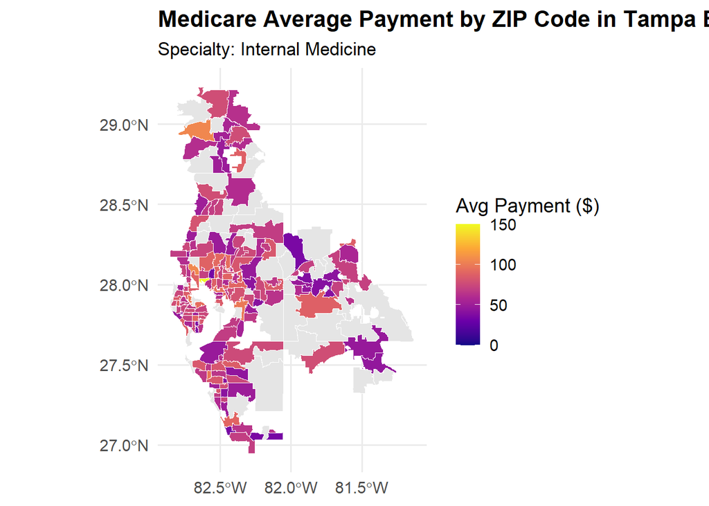

```r
# Choose specialty
selected_specialty <- "Internal Medicine"

# Filter and summarize
hm_filtered_data <- medicare_cleaned %>%
  filter(Provider_Type == selected_specialty) %>%
  group_by(Provider_Zip) %>%
  summarize(
    Avg_Payment = mean(Avg_Medicare_Payment, na.rm = TRUE),
    Providers = n(),
    .groups = "drop"
  )

# Merge with shapefile
merged_data <- zcta %>%
  left_join(hm_filtered_data, by = c("ZCTA5CE10" = "Provider_Zip"))

# Filter with Tampa Bay ZIP codes
tampa_map_data <- merged_data %>%
  filter(ZCTA5CE10 %in% tampa_bay_zips)

# Create heat map
tampa_plot <- ggplot(data = tampa_map_data) +
  geom_sf(aes(fill = Avg_Payment), color = "white", size = 0.2) +
  scale_fill_viridis_c(
    option = "plasma",
    na.value = "grey90",
    name = "Avg Payment ($)",
    limits = c(0, 150),
    breaks = c(0, 50, 100, 150),
    oob = scales::squish
  ) +
  labs(
    title = "Medicare Average Payment by ZIP Code in Tampa Bay",
    subtitle = paste("Specialty:", selected_specialty),
  ) +
  theme_minimal(base_size = 14) +
  theme(
    legend.position = "right",
    plot.title = element_text(face = "bold", size = 16),
    plot.subtitle = element_text(size = 13),
    plot.caption = element_text(size = 10, face = "italic")
  )
# Print map
tampa_plot
```

```r
# Save the heat map to the output folder
ggsave(
  filename = "Output/heatmap_transparent.png",
  plot = tampa_plot,
  width = 10,
  height = 6,
  dpi = 300
)

ggsave(
  filename = "Output/heatmap_opaque.png",
  plot = tampa_plot,
  width = 10,
  height = 6,
  dpi = 300,
  bg = "white"
)

# Here is a summary of our analysis based on Medicare payment data visualization:

# We analyzed average Medicare payments for providers specializing in Internal Medicine across Tampa Bay ZIP codes.
# This process began by loading and preparing a cleaned Medicare dataset and a shapefile representing Florida ZIP Code Tabulation Areas (ZCTAs).

# After filtering the data for the selected specialty ("Internal Medicine"), we calculated the average Medicare
# payment and the number of providers per ZIP code. This summarized dataset was then merged with the shapefile data
# to enable geographic plotting.

# Using ggplot2 and the sf package, we created a choropleth map showing the distribution of average Medicare payments
# across Tampa Bay. Areas with higher average payments appear in brighter plasma shades, while areas with lower payments
# or no data are shown in muted tones.

# The heatmap helps reveal regional disparities in Medicare reimbursements, highlighting ZIP codes with notably higher
# or lower average payments. These visual insights can inform further investigation into geographic trends in healthcare
# spending, potential inequities in reimbursement rates, or gaps in provider coverage for Internal Medicine in Tampa Bay.
```